# Hedonic Home Price Prediction for Boulder, CO

Anran Zheng, Ran Wang

2021/10/18

```r
knitr::opts_chunk$set(warning = FALSE, message = FALSE)
##Set Up

rm(list=ls())

library(tidyverse)
library(sf)
library(spdep)
library(caret)
library(ckanr)
library(FNN)
library(grid)
library(gridExtra)
library(ggcorrplot)
library(kableExtra)
library(jtools)
library(ggstance)
library(mapview)
library(tigris)
library(leaflet)
library(osmdata)
library(tidycensus)
library(stargazer)

root.dir = "https://raw.githubusercontent.com/urbanSpatial/Public-Policy-Analytics-Landing/master/DATA/"

source("https://raw.githubusercontent.com/urbanSpatial/Public-Policy-Analytics-Landing/master/functions.r")

palette5 <- c("#25CB10", "#5AB60C", "#8FA108",   "#C48C04", "#FA7800")

qBr <- function(df, variable, rnd) {
  if (missing(rnd)) {
    as.character(quantile(round(df[[variable]],0),
                          c(.01,.2,.4,.6,.8), na.rm=T))
  } else if (rnd == FALSE | rnd == F) {
    as.character(formatC(quantile(df[[variable]]), digits = 3),
                 c(.01,.2,.4,.6,.8), na.rm=T)
  }
}

st_c <- st_coordinates
```

## 1 Introduction

This project develops model to predict the home price for single-family housing in Boulder county, Colorado. Despite powerful models that Zillow possesses for home price prediction, the always unique context of places requires more refined and site-specific models that take local characteristics into consideration for price prediction. However, such a site-specific model is difficult to build because factors that influence home price tend to be correlate with each other within the system of real estate. Moreover, a site-specific model to Boulder has limited data for model training for Boulder is not a large county, a limitation that will harm the accuracy of the model. Responding to the request for a site-specific model, we develops a Hedonic model that deconstructs the home price into the values of constituent parts including internal characteristics such as housing quality, public services and amenities such as public transit, and spatial process such as the clustering of home price. We then use the model to predict the home price in relation to changes in aforementioned features.

The final model that we develop to predict home price in Boulder explains around 72% of the fluctuation of price with a 19% range of accuracy for each price that the model predicts. Our model has o average an absolute error of 130,000 for each price prediction; comparing to the mean of housing price ($739,555), our model has a decent accuracy for prediction. The mean absolute percentage error for all prediction is nearly randomly distributed in spatial term. While our model has a slightly higher mean absolute percentage error for neighborhoods with high income, the relatively small gap (3%) between the MAPE for high-income and low-income neighborhoods suggest that the model is generalizable. Thus, we believe that our model with good accuracy and generalizability will be useful for Zillow to predict home price in Boulder county, CO.

## 2 Data

### 2.1 Data Wrangling and Feature Engineering

We first download the county boundary data from the open data portal of Boulder county. We then use the county boundary to download key amenities–including parks, playgrounds, waters, restaurants, fast food, companies, and bus stations–spatial information from OpenStreetMap. We download spatial information of census tracts within Boulder and urban areas that the Census defines as densely developed areas with a population at least greater than 2,500 from the Census Bureau. We also manually collect k-12 school information from the website of Boulder Valley School District and clean it into a csv file.

We then convert raw variables into useful predictive features. We first eliminate outlinears that are significantly more expensive than the general housing stock in Boulder. To develop indicators, we calculate the age of homes and the distance to the nearest 1 ~ 3 amenities. We also create buffers to calculate how many amenities exist within certain miles of a house. We categorize numeric variables such as the number of bedrooms into categorical variables that divide the data into several categories such as house with more than 3 bedrooms. We spatial join the census tracts and urban areas to the housing characteristics so that each house is assigned to its census tract and urban status as either urban or non-urban. At last, we create lag price variable that represents the mean of the nearest 5 houses to account for the clustering effects of houses.

```r
Boulder_city <- st_read("C:/Users/zheng/Desktop/MUSA 508/508 midterm/City_of_Boulder_City_Limits.kml") %>%
  st_transform('EPSG:26913')%>%
  select(-Name, -Description)
Boulder_city <- st_union(Boulder_city)

Boulder.county=st_read("https://opendata.arcgis.com/api/v3/datasets/964b8f3b3dbe401bb28d49ac93d29dc4_0/downloads/data?format=kml&spatialRefId=4326")%>%
  st_as_sf()
Boulder.county.reproject<-Boulder.county %>%
  st_transform('EPSG:26913')%>%
  dplyr::select(-Name,-Description)

q0 <- opq(bbox = c(-105.6945,39.91297,-105.0528,40.26396))

st_bbox(Boulder.county.reproject)

housing <- st_read("C:/Users/zheng/Desktop/MUSA 508/508 midterm/studentData.geojson", crs = 'ESRI:102254')%>%
  st_transform('EPSG:26913')

housing <- housing %>%
  select(-Stories, -UnitCount)%>%
  mutate(age = 2021- EffectiveYear)%>%
  filter(nbrBedRoom < 10, carStorageSF < 3000)

housing <- housing[-2637,]

##Public Facilities

#parks

park <- add_osm_feature(opq = q0, key = 'leisure', value = "park") %>%
  osmdata_sf(.)

park.sf <- st_geometry(park$osm_points) %>%
  st_transform(4326) %>%
  st_sf() %>%
  cbind(., park$osm_points$name) %>%
  rename(NAME = park.osm_points.name)%>%
  st_transform('EPSG:26913')%>%
  st_intersection(Boulder.county.reproject,park.sf)%>%
  dplyr::select(geometry)

housing <- housing%>%
  mutate(park=nn_function(st_c(housing),st_c(park.sf),1))

#fast food

fast_food <- add_osm_feature(opq = q0, key = 'amenity', value = "fast_food") %>%
  osmdata_sf(.)

fast_food.sf <- st_geometry(fast_food$osm_points) %>%
  st_transform(4326) %>%
  st_sf() %>%
  cbind(., fast_food$osm_points$amenity) %>%
  rename(NAME = fast_food.osm_points.amenity)%>%
  st_transform('EPSG:26913')%>%
  st_intersection(Boulder.county.reproject,park.sf)

fast_food.sf<-
  fast_food.sf%>%
  dplyr::select(geometry)

housing$fastfood_buffer =
  st_buffer(housing, 800) %>% ##WHAT IS THE RIGHT PARAMETER
  aggregate(mutate(fast_food.sf, counter = 1),., sum) %>%
  pull(counter)


#water

water <- add_osm_feature(opq = q0, key = 'natural', value = "water") %>%
  osmdata_sf(.)

water.sf <- water$osm_points %>%
  dplyr::select(geometry) %>%
  st_as_sf(crs = 4326, agr = "constant") %>%
  distinct() %>%
  st_transform('EPSG:26913')%>%
  st_intersection(Boulder.county.reproject,park.sf)

housing <- housing%>%
  mutate(water_nn1=nn_function(st_c(housing),st_c(water.sf),1),
       water_nn2=nn_function(st_c(housing),st_c(water.sf),2),
       water_nn3=nn_function(st_c(housing),st_c(water.sf),3))

#playground

playground <- add_osm_feature(opq = q0, key = 'leisure', value = "playground") %>%
  osmdata_sf(.)

playground.sf <- st_geometry(playground$osm_points) %>%
  st_transform(4326) %>%
  st_sf() %>%
  cbind(., playground$osm_points$name) %>%
  rename(NAME = playground.osm_points.name)%>%
  st_transform('EPSG:26913')%>%
  st_intersection(Boulder.county.reproject,park.sf)%>%
  dplyr::select(geometry)

housing <- housing%>%
  mutate(playground=nn_function(st_c(housing),st_c(playground.sf),1))

#restaurant
restaurant <- add_osm_feature(opq = q0, key = 'amenity', value = "restaurant") %>%
  osmdata_sf(.)

restaurant.sf <- st_geometry(restaurant$osm_points) %>%
  st_transform(4326) %>%
  st_sf() %>%
  cbind(., restaurant$osm_points$amenity) %>%
  rename(NAME = restaurant.osm_points.amenity)%>%
  st_transform('EPSG:26913')%>%
  st_intersection(Boulder.county.reproject,park.sf)%>%
  dplyr::select(geometry)%>%
  distinct()

housing<-housing%>%
  mutate(
    restaurant_nn1 = nn_function(st_c(housing), st_c(restaurant.sf), 1),
    restaurant_nn2 = nn_function(st_c(housing), st_c(restaurant.sf), 2),
    restaurant_nn3 = nn_function(st_c(housing), st_c(restaurant.sf), 3))

##School District

school <- read.csv("C:/Users/zheng/Desktop/MUSA 508/508 midterm/school.csv")%>%
  st_as_sf(coords = c("LONGITUDE", "LATITUDE"), crs = 4326, agr = "constant")%>%
  st_transform('EPSG:26913')

school.sf <- school%>%
  dplyr::select(geometry) %>%
  st_as_sf(crs = 4326, agr = "constant")%>%
  st_transform('EPSG:26913')

housing$school_buffer =
  st_buffer(housing, 8000) %>% ##WHAT IS THE RIGHT PARAMETER
  aggregate(mutate(school.sf, counter = 1),., sum) %>%
  pull(counter)

housing <- housing%>%
  mutate(school=nn_function(st_c(housing),st_c(school.sf),1))

#Company

company <- add_osm_feature(opq = q0, key = 'office', value = "company") %>%
  osmdata_sf(.)

company.sf <- st_geometry(company$osm_points) %>%
  st_transform(4326) %>%
  st_sf() %>%
  cbind(., company$osm_points$office) %>%
  rename(NAME = company.osm_points.office)%>%
  st_transform('EPSG:26913')%>%
  st_intersection(Boulder.county.reproject,park.sf)%>%
  na.omit()

housing <- housing %>%
  mutate(company=nn_function(st_c(housing),st_c(company.sf),1))

#Bus station

bus_station <- add_osm_feature(opq = q0, key = 'amenity', value = "bus_station") %>%
  osmdata_sf(.)

bus_station.sf <- st_geometry(bus_station$osm_points) %>%
  st_transform(4326) %>%
  st_sf() %>%
  cbind(., bus_station$osm_points$amenity) %>%
  rename(NAME = bus_station.osm_points.amenity)%>%
  st_transform('EPSG:26913')%>%
  dplyr::select(geometry)%>%
  st_intersection(Boulder.county.reproject,park.sf)


housing <- housing%>%
  mutate(bus_stop_nn1=nn_function(st_c(housing),st_c(bus_station.sf),1),
         bus_stop_nn2=nn_function(st_c(housing),st_c(bus_station.sf),2),
         bus_stop_nn3=nn_function(st_c(housing),st_c(bus_station.sf),3))

##Internal Characteristics

housing <-
  housing %>%
  mutate(nbrBedRoom.cat = case_when(
    nbrBedRoom >= 0 & nbrBedRoom < 4  ~ "Up to 3 Bedrooms",
    nbrBedRoom >= 4 & nbrBedRoom < 5  ~ "4 Bedrooms",
    nbrBedRoom > 4                    ~ "5+ Bedrooms"))

##Spatial Process
#neighborhood
neighborhood <- get_acs(geography = "tract",
                             year = 2019,
                             variables = c("B06011_001E", #Median income in the past 12 months
                                          "B19013_001E"), #Median household income in the past 12 months
                             geometry = T,
                             state = "CO",
                             county = "Boulder",
                             output = "wide") %>%
  st_transform('EPSG:26913')%>%
  dplyr::select(-NAME,-B06011_001M,-B19013_001M,-B06011_001E,-B19013_001E)

#urban status
urban_area <- urban_areas(cb = FALSE, year = NULL)%>%
  st_transform('EPSG:26913')%>%
  select(NAME10, geometry)
urban_area <- st_intersection(Boulder.county.reproject, urban_area)%>%
  filter(NAME10 != "Denver--Aurora, CO")

housing <- st_join(housing, neighborhood, join = st_intersects)

housing <- st_join(housing, urban_area, join = st_intersects)

housing$NAME10[is.na(housing$NAME10)] <- 0

housing <- housing %>%
  rename(urban_status = NAME10)

housing$urban_status <- ifelse(housing$urban_status == "0", "non-urban", "urban")
```

```r
#the spatial lag of housing
Boulder <- housing %>%
  filter(toPredict == 0) %>%
  dplyr::select(-toPredict)
coords <- st_coordinates(Boulder)
neighborList <- knn2nb(knearneigh(coords, 5))
spatialWeights <- nb2listw(neighborList, style="W")

Boulder$lagPrice <- lag.listw(spatialWeights,
                                             Boulder$price)

housing$price[is.na(housing$price)] <- 0
coords.all <- st_coordinates(housing)
neighborList.all <- knn2nb(knearneigh(coords.all, 5))
spatialWeights.all <- nb2listw(neighborList.all, style="W")

housing$lagPrice <- lag.listw(spatialWeights.all,
                              housing$price)

housing$price[is.na(housing$price)] <- 0
coords.all <- st_coordinates(housing)
neighborList.all <- knn2nb(knearneigh(coords.all, 5))
spatialWeights.all <- nb2listw(neighborList.all, style="W")

housing$lagPrice <- lag.listw(spatialWeights.all,
                              housing$price)
```

### 2.2 Variable Descriptions

For variables in our final model, we select the following variables:

**Internal Characteristics**  
- age: age of the house calculated by 2021 minus the effective year of the house.  
- designCodeDscr: description of building’s design type  
- qualityCodeDscr: description of the quality of the house as determined by the government staff  
- TotalFinishedSF: total number of finished square feet without the basement squre feed  
- nbrBedRoom.cat : whether the house has more than 3 bedrooms  
- HeatingDscr: description of the type of heating system in the house  
- Roof_CoverDscr: the material used on the roof

**Public Service/Amenities**  
- park: distance from the house to the nearest park  
- school: distance from the house to the nearest school  
- restaurant_nn1: distance from the house to the nearest restaurant  
- bus_stop_nn1: distance from the house to the nearest bus station  
- company: distance from the house to the nearest company  
- water_nn1: distance from the house to the nearest water

**Spatial Process**  
- GEOID: census tract that the house belongs to  
- urban_status: whether the house is located in an urban area defined by the Census  
- lagPrice: the average sale price of the house’s 5 nearest neighbors

The summary statistics for all numerical varibles are presented below.

```r
final_vars<-st_drop_geometry(Boulder)%>%
  select(
         price,
                                         age,
                                         GEOID,
                                         urban_status,
                                         designCodeDscr,
                                         qualityCodeDscr,
                                         TotalFinishedSF,
                                         nbrBedRoom.cat,
                                         HeatingDscr,
                                         Roof_CoverDscr,
                                         park,
                                         school,
                                         restaurant_nn1,
                                         bus_stop_nn1,
                                         company,
                                         water_nn1,
                                         lagPrice)%>% na.omit()
stargazer(final_vars,type = "text",title = "Table 1. summary statistics with chosen variable descriptions")
```

```
##
## Table 1. summary statistics with chosen variable descriptions
## ======================================================================================
## Statistic         N       Mean      St. Dev.     Min   Pctl(25)   Pctl(75)     Max
## --------------------------------------------------------------------------------------
## price           11,259 746,123.700 543,627.200 10,000   452,600   831,100   7,350,000
## age             11,259   23.300      17.476       0       11         32        142
## TotalFinishedSF 11,259  1,953.673    889.723      0      1,276    2,442.5     10,188
## park            11,259   669.182    1,375.010   7.590   154.185   501.759   10,712.720
## school          11,259  6,110.231   6,185.961  12.666   849.973  12,282.800 22,328.780
## restaurant_nn1  11,259  1,444.577   1,473.535  10.489   581.046  1,723.857  12,111.570
## bus_stop_nn1    11,259 11,891.590   7,875.543  105.256 4,588.042 19,497.640 35,165.250
## company         11,259  6,830.712   6,154.506  50.168  1,364.029 12,533.640 31,577.050
## water_nn1       11,259   675.573     520.170   11.318   340.253   869.275   5,028.900
## lagPrice        11,259 733,469.600 427,418.800 137,900  461,870   839,880   3,849,000
## --------------------------------------------------------------------------------------
```

### 2.3 Data Selection: Correlation Matrix and Correlation Plots

Below if the correlation matrix of all variables that we develop. We select and delete variables based on the correlation matrix. If two variables have a high correlation, we only choose one to include in our model.

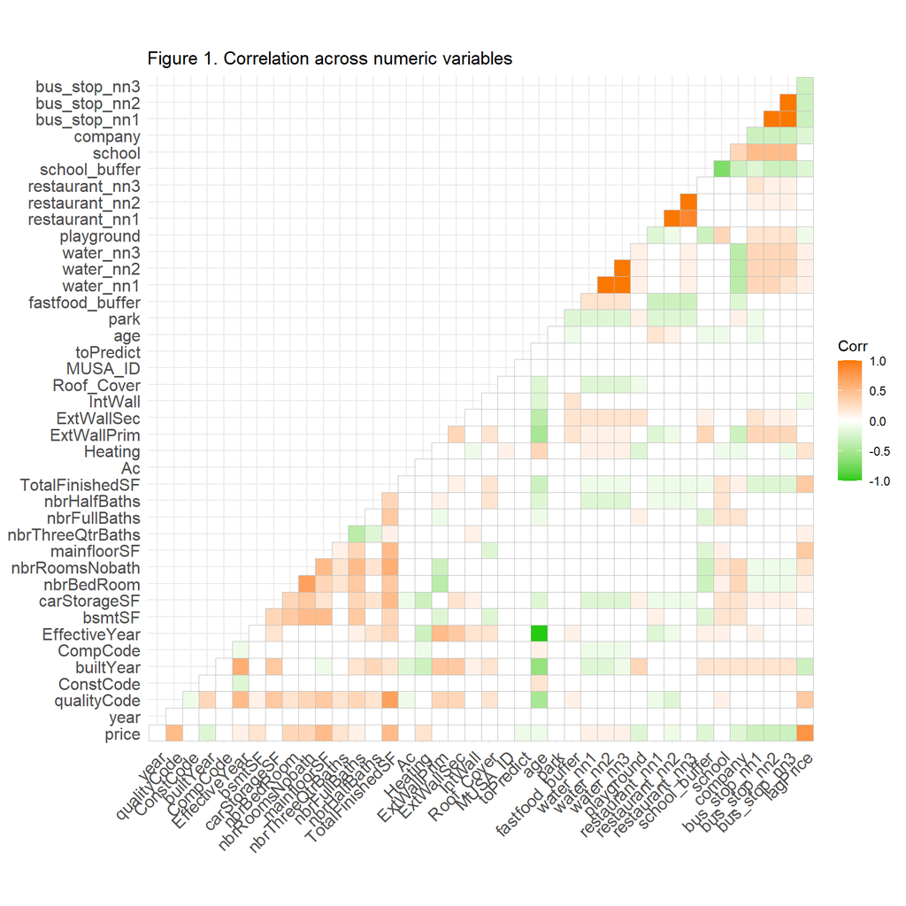

```r
numericVars <-
  select_if(st_drop_geometry(housing), is.numeric) %>% na.omit()

ggcorrplot(
  round(cor(numericVars), 1),
  p.mat = cor_pmat(numericVars),
  colors = c("#25CB10", "white", "#FA7800"),
  type="lower",
  insig = "blank") +
  labs(title = "Figure 1. Correlation across numeric variables")
```

For categorical variables that cannot be incorporated into the correlation matrix, we plot price as a function of categorical variables to see if there is a correlation. Below are the plots for variables of interest that show a correlation to the home price.

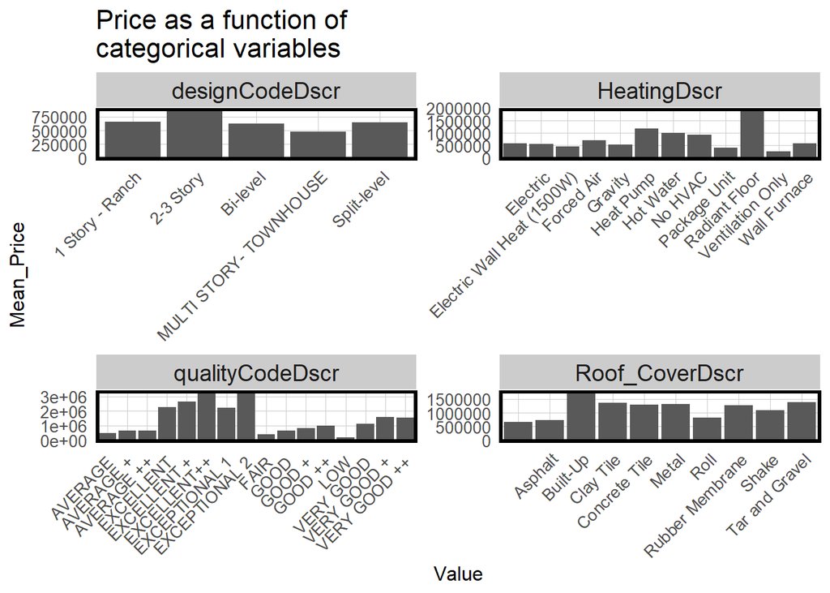

```r
st_drop_geometry(housing) %>%
  dplyr::select(price,
                designCodeDscr,
                qualityCodeDscr,
                HeatingDscr,
                Roof_CoverDscr) %>%
  gather(Variable, Value, -price) %>%
  ggplot(aes(Value, price)) +
  geom_bar(position = "dodge", stat = "summary", fun.y = "mean") +
  facet_wrap(~Variable, ncol = 2, scales = "free") +
  labs(title = "Price as a function of\ncategorical variables", y = "Mean_Price") +
  plotTheme() + theme(axis.text.x = element_text(angle = 45, hjust = 1))
```

### 2.4 Price Correlation Scatter Plots

The scatter plots below show the home price correlated with 4 different variables of interest. The age of house is negatively correlated with the home price, meaning that the older a house is, the lower the sale price will be; yet the correlation line is rather gradual, potentially skewed by a few old houses with high value. The distance to the nearest bus stop is negatively correlate with home price, suggesting that the home price is likely to decrease with the decrease in accessibility to public transit. The distance to the nearest company site is negatively correlate with home price, suggesting that more far away a house is from company sites, the lower the sale price will be; this correlation indicates the relationship between home price and potential job opportunity. The distance to the nearest school site is also negatively correlate with home price, meaning that more distant a house is to school, the lower the sale price will be.

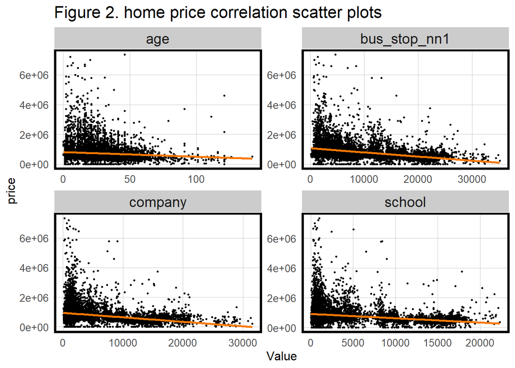

```r
st_drop_geometry(housing) %>%
  dplyr::select(price, company, school, age, bus_stop_nn1) %>%
  gather(Variable, Value, -price) %>%
  ggplot(aes(Value, price)) +
  geom_point(size = .5) +
  geom_smooth(method = "lm", se=T, colour = "#FA7800") +
  facet_wrap(~Variable, ncol = 2, scales = "free") +
  labs(title = "Figure 2. home price correlation scatter plots") +
  plotTheme()
```

### 2.5 Map Home Sale Price

The map below visualizes the distribution of sale prices in Boulder county. The higher price tends to concentrate in the Boulder city, and the lower price tends to concentrate in Northeast Boulder and to scatter over the less populated parts in the county.

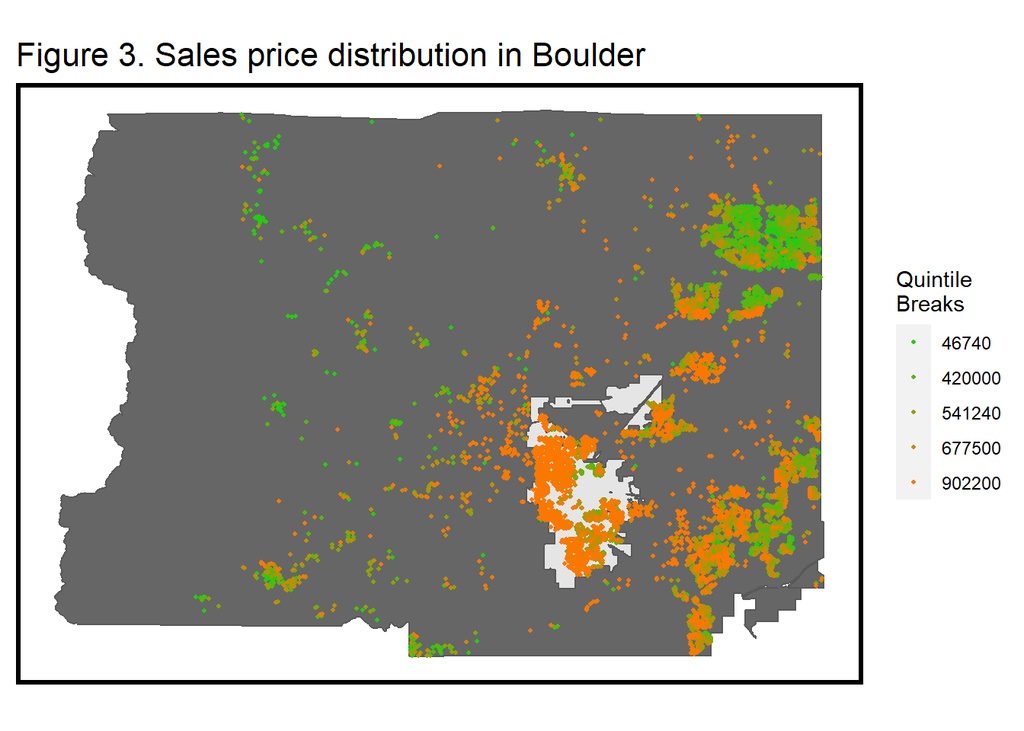

```r
ggplot()  +
  geom_sf(data = Boulder.county.reproject, fill = "grey40") +
  geom_sf(data = Boulder_city)+
  geom_sf(data = housing, aes(colour = q5(price)),
          show.legend = "point", size = .75) +
  scale_colour_manual(values = palette5,
                      labels=qBr(housing,"price"),
                      name="Quintile\nBreaks") +
  labs(title="Figure 3. Sales price distribution in Boulder") +
  mapTheme()
```

### 2.6 Maps of Interesting Independent Variables

The following maps show the spatial distribution of three independent variables: urban status, distance to nearest bus station, and the design style of house. Each variable has its own distribution pattern, all with certain degree of clustering that does not resonate with a single spatial process, say, urban status. The different patterns of clustering for independent variables suggest the importance to include all of them into the model.

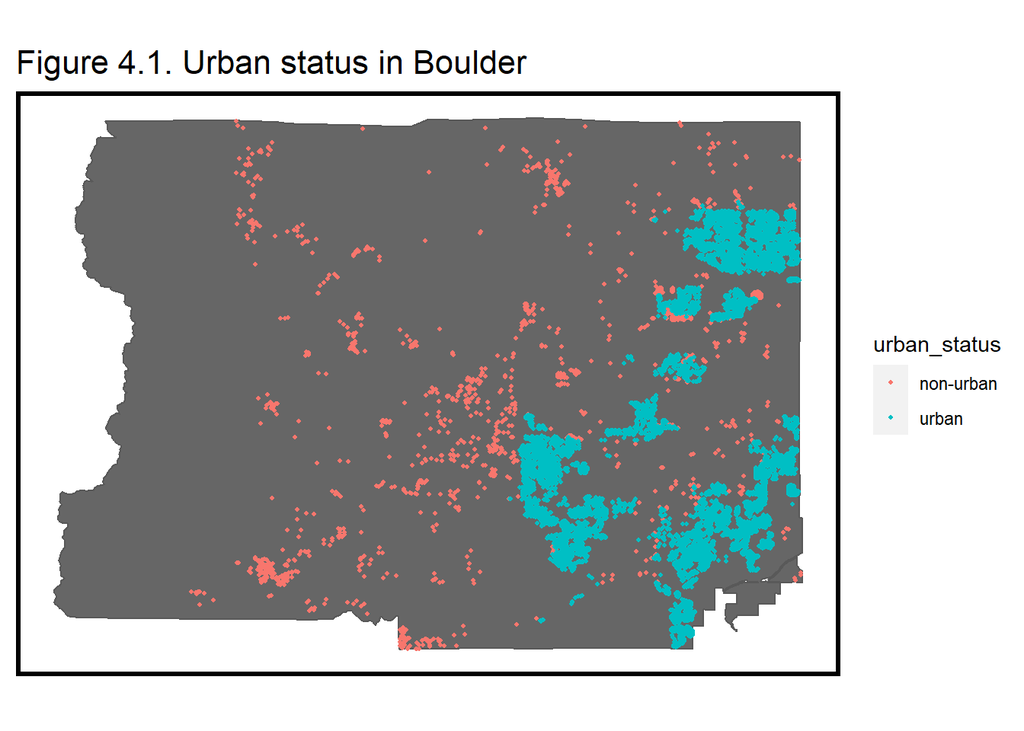

```r
#urban status
ggplot() +
  geom_sf(data = Boulder.county.reproject, fill = "grey40") +
  geom_sf(data = housing, aes(colour = urban_status),
          show.legend = "point", size = .75) +
  labs(title="Figure 4.1. Urban status in Boulder") +
  mapTheme()
```

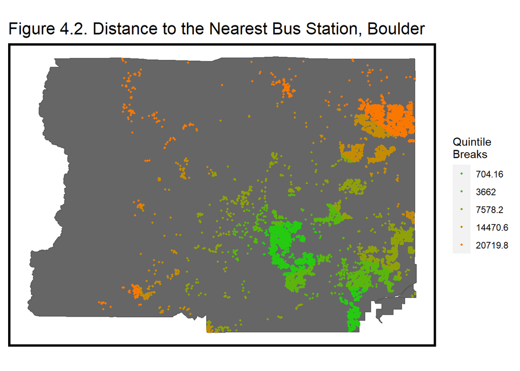

```r
#distance to bus station
ggplot() +
  geom_sf(data = Boulder.county.reproject, fill = "grey40") +
  geom_sf(data = housing, aes(colour = q5(bus_stop_nn1)),
          show.legend = "point", size = .75) +
  scale_colour_manual(values = palette5,
                      labels=qBr(housing,"bus_stop_nn1"),
                      name="Quintile\nBreaks") +
  labs(title="Figure 4.2. Distance to the Nearest Bus Station, Boulder") +
  mapTheme()
```

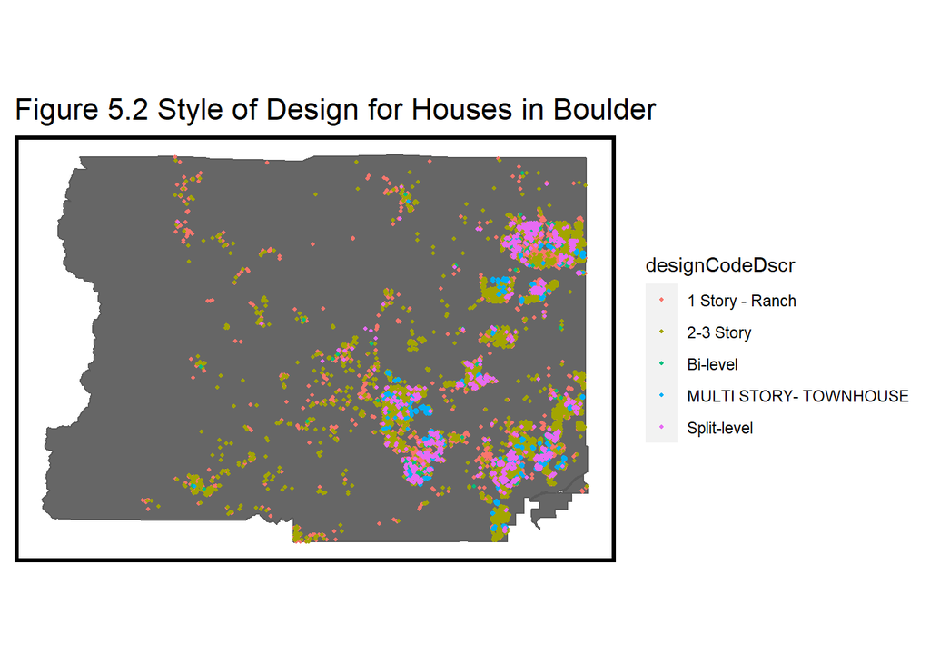

```r
#housing design
ggplot() +
  geom_sf(data = Boulder.county.reproject, fill = "grey40") +
  geom_sf(data = housing, aes(colour = designCodeDscr),
          show.legend = "point", size = .75) +
  labs(title="Figure 5.2 Style of Design for Houses in Boulder") +
  mapTheme()
```

## 3 Methods

### 3.1 Split the training and testing datasets

We first split our data into training for 75% and testing sets for 25%. According to the correlation matrix above (Figure 1), we should eliminate the multicollinearity as possible to ensure that all these variables should be independent.

```r
set.seed(645)
inTrain <- createDataPartition(
  y = paste(Boulder$designCodeDscr,
  Boulder$nbrBedRoom.cat,
  Boulder$HeatingDscr,
  Boulder$Roof_CoverDscr,
  Boulder$GEOID),
  p = .75, list = FALSE)

Boulder.training <- Boulder[inTrain,]
Boulder.testing  <- Boulder[-inTrain,]
housing.test.nhood <- Boulder.testing
```

### 3.2 OLS regression model

After selecting the variables from correlation matrix, we conducted OLS regression analysis on these variables with different combinations. We compare the results of them by looking at the following indexes: 1. P-value and estimated coefficients of each variables. P-values should be significant as possible.  
2. The final F-statistics  
3. The adjusted R square, which should be greater as possible.  
After several trials, we finally selected the following variables for our training datasets.

**Internal characteristics**  
- Age  
- designCodeDscr  
- qualityCodeDscr  
- TotalFinishedSF  
- nbrBedRoom.cat  
- HeatingDscr  
- Roof_CoverDscr

**Public services**  
-park  
-school  
-restaurant_nn1  
-bus_stop_nn1  
-company  
-water_nn1

**Spatial structure**  
-neighbourhoods  
-urban status  
-price lag

```r
##Regression 1
reg1 <- lm(price ~ ., data = st_drop_geometry(housing) %>%
             dplyr::select(price,
                                age,
                                urban_status,
                           GEOID,
                                designCodeDscr,
                                qualityCodeDscr,
                                TotalFinishedSF,
                                nbrBedRoom.cat,
                                HeatingDscr,
                                Roof_CoverDscr,
                                park,
                                school,
                                restaurant_nn1,
                                bus_stop_nn1,
                                company,
                                water_nn1,
                                lagPrice))
summary(reg1)
```

```
##
## Call:
## lm(formula = price ~ ., data = st_drop_geometry(housing) %>%
##     dplyr::select(price, age, urban_status, GEOID, designCodeDscr,
##         qualityCodeDscr, TotalFinishedSF, nbrBedRoom.cat, HeatingDscr,
##         Roof_CoverDscr, park, school, restaurant_nn1, bus_stop_nn1,
##         company, water_nn1, lagPrice))
##
## Residuals:
##      Min       1Q   Median       3Q      Max
## -3176880   -78418    -1262    76986  6300544
##
## Coefficients:
##                                         Estimate Std. Error t value Pr(>|t|)
## (Intercept)                            9.890e+05  5.113e+04  19.344  < 2e-16
## age                                   -1.742e+03  2.428e+02  -7.175 7.70e-13
## urban_statusurban                     -3.270e+04  1.490e+04  -2.195 0.028213
## GEOID08013012102                      -3.028e+05  3.100e+04  -9.766  < 2e-16
## GEOID08013012103                      -2.478e+05  3.792e+04  -6.533 6.72e-11
## GEOID08013012104                      -2.119e+05  4.005e+04  -5.291 1.24e-07
## GEOID08013012105                      -3.466e+05  3.800e+04  -9.120  < 2e-16
## GEOID08013012201                      -2.066e+04  4.086e+04  -0.506 0.613155
## GEOID08013012202                      -3.244e+05  5.293e+04  -6.129 9.12e-10
## GEOID08013012203                      -5.696e+05  4.176e+04 -13.638  < 2e-16
## GEOID08013012204                       2.745e+05  7.596e+04   3.613 0.000304
## GEOID08013012300                      -1.079e+05  2.125e+05  -0.508 0.611730
## GEOID08013012401                      -2.236e+05  4.252e+04  -5.258 1.48e-07
## GEOID08013012501                      -4.875e+05  5.215e+04  -9.349  < 2e-16
## GEOID08013012505                      -2.382e+05  3.573e+04  -6.666 2.75e-11
## GEOID08013012507                      -4.986e+05  4.128e+04 -12.077  < 2e-16
## GEOID08013012508                      -4.697e+05  5.064e+04  -9.276  < 2e-16
## GEOID08013012509                      -3.712e+05  4.137e+04  -8.974  < 2e-16
## GEOID08013012510                      -1.952e+05  4.012e+04  -4.866 1.16e-06
## GEOID08013012511                      -5.052e+05  5.134e+04  -9.839  < 2e-16
## GEOID08013012603                      -4.889e+05  3.979e+04 -12.287  < 2e-16
## GEOID08013012605                      -5.335e+05  1.251e+05  -4.265 2.01e-05
## GEOID08013012607                      -5.077e+05  7.448e+04  -6.817 9.80e-12
## GEOID08013012608                      -5.209e+05  4.435e+04 -11.746  < 2e-16
## GEOID08013012701                      -5.422e+05  3.605e+04 -15.043  < 2e-16
## GEOID08013012705                      -5.717e+05  5.437e+04 -10.514  < 2e-16
```

[output cut: 204 more lines]

```
## Roof_CoverDscrShake                   .
## Roof_CoverDscrTar and Gravel
## park                                  **
## school
## restaurant_nn1                        *
## bus_stop_nn1                          *
## company
## water_nn1
## lagPrice                              ***
## ---
## Signif. codes:  0 '***' 0.001 '**' 0.01 '*' 0.05 '.' 0.1 ' ' 1
##
## Residual standard error: 298400 on 11240 degrees of freedom
## Multiple R-squared:  0.7042, Adjusted R-squared:  0.7011
## F-statistic: 226.8 on 118 and 11240 DF,  p-value: < 2.2e-16
```

### 3.3 Accounting for neighbourhoods effects

```r
reg.training <-
  lm(price ~ ., data = as.data.frame(Boulder.training) %>%
       dplyr::select(price,
                                age,
                                designCodeDscr,
                                qualityCodeDscr,
                                TotalFinishedSF,
                                nbrBedRoom.cat,
                                HeatingDscr,
                                Roof_CoverDscr,
                                park,
                                school,
                                restaurant_nn1,
                                bus_stop_nn1,
                                company,
                                water_nn1))
summary(reg.training)
```

```
##
## Call:
## lm(formula = price ~ ., data = as.data.frame(Boulder.training) %>%
##     dplyr::select(price, age, designCodeDscr, qualityCodeDscr,
##         TotalFinishedSF, nbrBedRoom.cat, HeatingDscr, Roof_CoverDscr,
##         park, school, restaurant_nn1, bus_stop_nn1, company,
##         water_nn1))
##
## Residuals:
##      Min       1Q   Median       3Q      Max
## -2735250  -126430   -21526    85208  6692192
##
## Coefficients:
##                                         Estimate Std. Error t value Pr(>|t|)
## (Intercept)                            7.858e+05  4.396e+04  17.876  < 2e-16
## age                                    1.215e+03  2.876e+02   4.225 2.41e-05
## designCodeDscr2-3 Story               -6.035e+04  9.885e+03  -6.105 1.07e-09
## designCodeDscrBi-level                 4.440e+04  2.162e+04   2.054 0.040045
## designCodeDscrMULTI STORY- TOWNHOUSE  -2.425e+05  1.414e+04 -17.156  < 2e-16
## designCodeDscrSplit-level              8.595e+03  1.482e+04   0.580 0.561841
## qualityCodeDscrAVERAGE +              -7.745e+03  1.633e+04  -0.474 0.635247
## qualityCodeDscrAVERAGE ++              3.312e+04  1.671e+04   1.982 0.047551
## qualityCodeDscrEXCELLENT               1.306e+06  3.736e+04  34.944  < 2e-16
## qualityCodeDscrEXCELLENT +             1.545e+06  8.511e+04  18.151  < 2e-16
## qualityCodeDscrEXCELLENT++             2.214e+06  6.711e+04  32.996  < 2e-16
## qualityCodeDscrEXCEPTIONAL 1           1.328e+06  8.559e+04  15.516  < 2e-16
## qualityCodeDscrEXCEPTIONAL 2           1.719e+06  2.102e+05   8.177 3.30e-16
## qualityCodeDscrFAIR                   -1.226e+05  4.256e+04  -2.880 0.003980
## qualityCodeDscrGOOD                    7.516e+04  1.148e+04   6.549 6.10e-11
## qualityCodeDscrGOOD +                  1.040e+05  1.964e+04   5.293 1.23e-07
## qualityCodeDscrGOOD ++                 2.094e+05  1.788e+04  11.711  < 2e-16
## qualityCodeDscrLOW                    -2.305e+05  9.230e+04  -2.498 0.012515
## qualityCodeDscrVERY GOOD               3.090e+05  1.913e+04  16.159  < 2e-16
## qualityCodeDscrVERY GOOD +             7.182e+05  3.387e+04  21.208  < 2e-16
## qualityCodeDscrVERY GOOD ++            7.360e+05  2.784e+04  26.435  < 2e-16
## TotalFinishedSF                        1.489e+02  7.416e+00  20.080  < 2e-16
## nbrBedRoom.cat5+ Bedrooms              4.044e+04  1.225e+04   3.301 0.000968
## nbrBedRoom.catUp to 3 Bedrooms        -9.786e+03  9.203e+03  -1.063 0.287619
## HeatingDscrElectric                   -7.088e+04  4.325e+04  -1.639 0.101257
## HeatingDscrElectric Wall Heat (1500W)  2.158e+03  2.501e+05   0.009 0.993113
```

[output cut: 66 more lines]

```
## Roof_CoverDscrRubber Membrane         **
## Roof_CoverDscrShake
## Roof_CoverDscrTar and Gravel
## park
## school                                ***
## restaurant_nn1                        ***
## bus_stop_nn1                          ***
## company                               ***
## water_nn1                             **
## ---
## Signif. codes:  0 '***' 0.001 '**' 0.01 '*' 0.05 '.' 0.1 ' ' 1
##
## Residual standard error: 349100 on 9069 degrees of freedom
## Multiple R-squared:  0.6059, Adjusted R-squared:  0.6038
## F-statistic: 284.6 on 49 and 9069 DF,  p-value: < 2.2e-16
```

```r
Boulder.testing <-
  Boulder.testing %>%
  mutate(Regression = "Baseline Regression",
         price.Predict = predict(reg.training, Boulder.testing),
         price.Error = price.Predict - price,
         price.AbsError = abs(price.Predict - price),
         price.APE = (abs(price.Predict - price)) /
           price.Predict)%>%
  filter(price < 8000000)

##Generalizibility
fitControl <- trainControl(method = "cv", number = 100)
set.seed(825)

reg.cv <-
  train(price ~ ., data = st_drop_geometry(Boulder.training) %>%
          dplyr::select(price,
                                age,
                                urban_status,
                                designCodeDscr,
                                qualityCodeDscr,
                                TotalFinishedSF,
                                nbrBedRoom.cat,
                                HeatingDscr,
                                Roof_CoverDscr,
                                park,
                                school,
                                restaurant_nn1,
                                bus_stop_nn1,
                                company,
                                water_nn1,
                                lagPrice),
        method = "lm", trControl = fitControl, na.action = na.pass)

reg.cv
```

```
## Linear Regression
##
## 9119 samples
##   15 predictor
##
## No pre-processing
## Resampling: Cross-Validated (100 fold)
## Summary of sample sizes: 9029, 9028, 9027, 9028, 9028, 9027, ...
## Resampling results:
##
##   RMSE      Rsquared  MAE
##   293539.7  0.723245  155487.2
##
## Tuning parameter 'intercept' was held constant at a value of TRUE
```

```r
mean(reg.cv$resample[,3])
```

```
## [1] 155487.2
```

## 4 Results

### 4.1 Results of training dataset

```r
reg.nhood <- lm(price ~ ., data = st_drop_geometry(Boulder.training) %>%
                  dplyr::select(price,
                                age,
                                GEOID,
                                urban_status,
                                designCodeDscr,
                                qualityCodeDscr,
                                TotalFinishedSF,
                                nbrBedRoom.cat,
                                HeatingDscr,
                                Roof_CoverDscr,
                                park,
                                school,
                                restaurant_nn1,
                                bus_stop_nn1,
                                company,
                                water_nn1,
                                lagPrice))
kable(tidy(reg.nhood),caption = "Table 2. summary results of training dataset") %>% kable_styling()
```

Table 2. summary results of training dataset

| term | estimate | std.error | statistic | p.value |
| --- | --- | --- | --- | --- |
| (Intercept) | 8.893211e+05 | 5.492575e+04 | 16.1913341 | 0.0000000 |
| age | -1.694320e+03 | 2.611500e+02 | -6.4879161 | 0.0000000 |
| GEOID08013012102 | -2.577510e+05 | 3.369440e+04 | -7.6496687 | 0.0000000 |
| GEOID08013012103 | -2.123701e+05 | 4.054170e+04 | -5.2383127 | 0.0000002 |
| GEOID08013012104 | -1.174276e+05 | 4.256825e+04 | -2.7585731 | 0.0058172 |
| GEOID08013012105 | -2.932291e+05 | 4.040904e+04 | -7.2565233 | 0.0000000 |
| GEOID08013012201 | 3.267974e+04 | 4.249490e+04 | 0.7690275 | 0.4418972 |
| GEOID08013012202 | -2.710871e+05 | 5.489525e+04 | -4.9382611 | 0.0000008 |
| GEOID08013012203 | -4.985736e+05 | 4.551599e+04 | -10.9538128 | 0.0000000 |
| GEOID08013012204 | 4.151615e+05 | 7.882404e+04 | 5.2669402 | 0.0000001 |
| GEOID08013012300 | -4.833522e+04 | 2.068784e+05 | -0.2336407 | 0.8152693 |
| GEOID08013012401 | -1.453286e+05 | 4.542295e+04 | -3.1994531 | 0.0013817 |
| GEOID08013012501 | -4.249189e+05 | 5.496778e+04 | -7.7303265 | 0.0000000 |
| GEOID08013012505 | -1.728226e+05 | 3.823529e+04 | -4.5199752 | 0.0000063 |
| GEOID08013012507 | -4.310379e+05 | 4.498063e+04 | -9.5827461 | 0.0000000 |
| GEOID08013012508 | -4.103342e+05 | 5.427016e+04 | -7.5609540 | 0.0000000 |
| GEOID08013012509 | -3.000941e+05 | 4.405788e+04 | -6.8113613 | 0.0000000 |
| GEOID08013012510 | -1.502248e+05 | 4.255698e+04 | -3.5299688 | 0.0004177 |
| GEOID08013012511 | -4.559635e+05 | 5.332887e+04 | -8.5500310 | 0.0000000 |
| GEOID08013012603 | -4.269271e+05 | 4.257071e+04 | -10.0286588 | 0.0000000 |
| GEOID08013012605 | -4.726432e+05 | 1.223867e+05 | -3.8618850 | 0.0001133 |
| GEOID08013012607 | -4.386106e+05 | 7.926728e+04 | -5.5333128 | 0.0000000 |
| GEOID08013012608 | -4.541142e+05 | 4.748705e+04 | -9.5629048 | 0.0000000 |
| GEOID08013012701 | -5.160196e+05 | 3.922808e+04 | -13.1543424 | 0.0000000 |
| GEOID08013012705 | -5.125036e+05 | 5.884075e+04 | -8.7100105 | 0.0000000 |
| GEOID08013012707 | -2.841530e+05 | 6.286795e+04 | -4.5198394 | 0.0000063 |
| GEOID08013012708 | -5.351398e+05 | 4.693536e+04 | -11.4016342 | 0.0000000 |
| GEOID08013012709 | -5.198687e+05 | 5.813934e+04 | -8.9417715 | 0.0000000 |
| GEOID08013012710 | -3.547513e+05 | 4.282652e+04 | -8.2834511 | 0.0000000 |
| GEOID08013012800 | -6.966864e+05 | 5.593500e+04 | -12.4552863 | 0.0000000 |

[output cut: 89 more lines]

```r
summary(reg.nhood)
```

```
##
## Call:
## lm(formula = price ~ ., data = st_drop_geometry(Boulder.training) %>%
##     dplyr::select(price, age, GEOID, urban_status, designCodeDscr,
##         qualityCodeDscr, TotalFinishedSF, nbrBedRoom.cat, HeatingDscr,
##         Roof_CoverDscr, park, school, restaurant_nn1, bus_stop_nn1,
##         company, water_nn1, lagPrice))
##
## Residuals:
##      Min       1Q   Median       3Q      Max
## -2230996   -84580    -5029    75868  6271992
##
## Coefficients:
##                                         Estimate Std. Error t value Pr(>|t|)
## (Intercept)                            8.893e+05  5.493e+04  16.191  < 2e-16
## age                                   -1.694e+03  2.612e+02  -6.488 9.16e-11
## GEOID08013012102                      -2.578e+05  3.369e+04  -7.650 2.22e-14
## GEOID08013012103                      -2.124e+05  4.054e+04  -5.238 1.66e-07
## GEOID08013012104                      -1.174e+05  4.257e+04  -2.759 0.005817
## GEOID08013012105                      -2.932e+05  4.041e+04  -7.257 4.30e-13
## GEOID08013012201                       3.268e+04  4.249e+04   0.769 0.441897
## GEOID08013012202                      -2.711e+05  5.490e+04  -4.938 8.02e-07
## GEOID08013012203                      -4.986e+05  4.552e+04 -10.954  < 2e-16
## GEOID08013012204                       4.152e+05  7.882e+04   5.267 1.42e-07
## GEOID08013012300                      -4.834e+04  2.069e+05  -0.234 0.815269
## GEOID08013012401                      -1.453e+05  4.542e+04  -3.199 0.001382
## GEOID08013012501                      -4.249e+05  5.497e+04  -7.730 1.19e-14
## GEOID08013012505                      -1.728e+05  3.824e+04  -4.520 6.26e-06
## GEOID08013012507                      -4.310e+05  4.498e+04  -9.583  < 2e-16
## GEOID08013012508                      -4.103e+05  5.427e+04  -7.561 4.39e-14
## GEOID08013012509                      -3.001e+05  4.406e+04  -6.811 1.03e-11
## GEOID08013012510                      -1.502e+05  4.256e+04  -3.530 0.000418
## GEOID08013012511                      -4.560e+05  5.333e+04  -8.550  < 2e-16
## GEOID08013012603                      -4.269e+05  4.257e+04 -10.029  < 2e-16
## GEOID08013012605                      -4.726e+05  1.224e+05  -3.862 0.000113
## GEOID08013012607                      -4.386e+05  7.927e+04  -5.533 3.23e-08
## GEOID08013012608                      -4.541e+05  4.749e+04  -9.563  < 2e-16
## GEOID08013012701                      -5.160e+05  3.923e+04 -13.154  < 2e-16
## GEOID08013012705                      -5.125e+05  5.884e+04  -8.710  < 2e-16
## GEOID08013012707                      -2.842e+05  6.287e+04  -4.520 6.27e-06
```

[output cut: 204 more lines]

```
## Roof_CoverDscrShake                   .
## Roof_CoverDscrTar and Gravel
## park                                  *
## school
## restaurant_nn1                        *
## bus_stop_nn1                          *
## company
## water_nn1
## lagPrice                              ***
## ---
## Signif. codes:  0 '***' 0.001 '**' 0.01 '*' 0.05 '.' 0.1 ' ' 1
##
## Residual standard error: 290000 on 9000 degrees of freedom
## Multiple R-squared:  0.7302, Adjusted R-squared:  0.7266
## F-statistic: 206.4 on 118 and 9000 DF,  p-value: < 2.2e-16
```